# Le Commerce Mondial

Cours L3 Géographie 2025

Claude Grasland

2025-02-03

# INTRODUCTION

## De quoi le commerce-est-il le nom ?

“L’effet naturel du commerce est de porter à la paix. Deux nations qui négocient ensemble se rendent réciproquement dépendantes : si l’une a intérêt d’acheter, l’autre à intérêt de vendre ; et toutes les unions sont fondées sur les besoins mutuels.”

**Montesquieu, 1689-1755**

[figure not shown]

## De quoi le commerce-est-il le nom ?

“La guerre est antérieure au commerce ; car la guerre et le commerce ne sont que deux moyens différents d’atteindre le même but : celui de posséder ce que l’on désire.”

“La guerre est l’impulsion, le commerce est le calcul. Mais par là même il doit venir une époque où le commerce remplace la guerre.”

**Benjamin Constant, 1767-1830**

[figure not shown]

## De quoi le commerce-est-il le nom ?

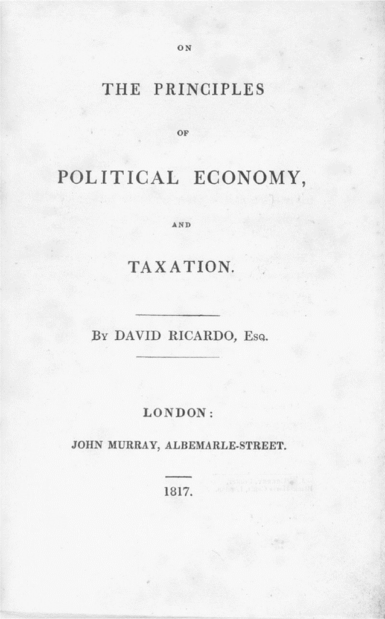

## De quoi le commerce-est-il le nom ?

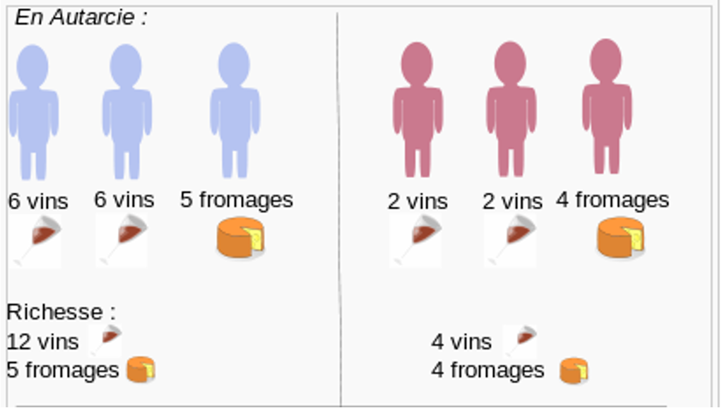

[figure not shown]

Le pays A dispose d’un avantage absolu en matière de productivité journalière, aussi bien pour le vin que pour le fromage.

Le pays B dispose d’un avantage comparatif plus important pour le fromage que pour le vin.

## De quoi le commerce-est-il le nom ?

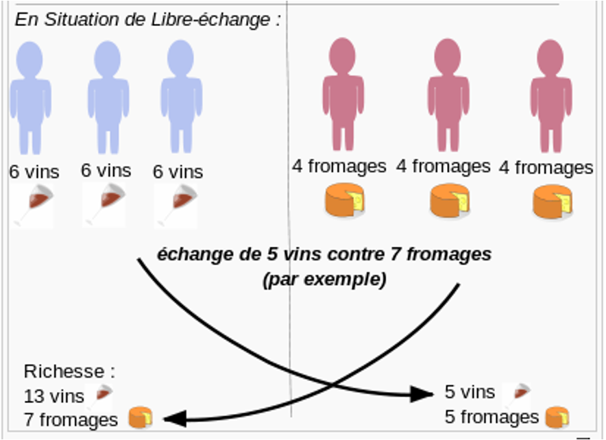

**THEORIE DU LIBRE ECHANGE** : Si chaque pays se spécialise dans la production où il est le plus performant ou le moins contre-performant (*avantage comparatif*) et s’il échange avec l’autre pays sa production chacun est théoriquement gagnant…

## Pour le libre échange …

[figure not shown]

[figure not shown]

## Contre le libre échange …

[figure not shown]

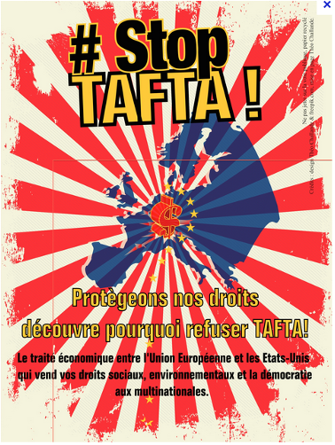

# PUISSANCE COMMERCIALE DES PAYS DU MONDE EN 2019

## Origine des données

Nous avons utilisé les données de la Banque Mondiale pour l’année 2019 afin de dresser un portait du Monde avant la crise de la COVID-19 qui a perturbé l’ensemble des échanges mondiaux.

- Ces données sont accessibles librement via la base de données [WITS](https://wits.worldbank.org/)
- Elles ne comportent pas les pays contestés, notamment Taiwan ou le Kosovo.
- Elles décomposent certains états (e.g. Chine/TaiWan/Macao)
- Elles ne tiennent pas compte des unions douanières (UE, ALENA, ASEAN, …)
- Pour les croisements avec le PIB on utilise la moyenne 2015-2019

## Exportations 2019 (top 20)

| code | pays | rang | valeur | pct | cumpct |
| --- | --- | --- | --- | --- | --- |
| CHN | China | 1 | 2,443.4163 | 14.192537 | 14.19254 |
| DEU | Germany | 2 | 1,470.3348 | 8.540412 | 22.73295 |
| USA | United States | 3 | 1,365.6594 | 7.932407 | 30.66536 |
| JPN | Japan | 4 | 662.6142 | 3.848782 | 34.51414 |
| NLD | Netherlands | 5 | 563.7057 | 3.274274 | 37.78841 |
| FRA | France | 6 | 553.2031 | 3.213270 | 41.00168 |
| KOR | Korea | 7 | 526.4512 | 3.057882 | 44.05956 |
| HKG | Hong Kong | 8 | 523.9010 | 3.043069 | 47.10263 |
| ITA | Italy | 9 | 507.7116 | 2.949033 | 50.05167 |
| GBR | United Kingdom | 10 | 453.0345 | 2.631442 | 52.68311 |
| BEL | Belgium | 11 | 444.1320 | 2.579732 | 55.26284 |
| RUS | Russia | 12 | 421.5792 | 2.448735 | 57.71158 |
| CAN | Canada | 13 | 408.3601 | 2.371952 | 60.08353 |
| SGP | Singapore | 14 | 373.9425 | 2.172038 | 62.25557 |
| MEX | Mexico | 15 | 346.9749 | 2.015397 | 64.27096 |
| IND | India | 16 | 319.1322 | 1.853673 | 66.12464 |
| ESP | Spain | 17 | 315.8612 | 1.834674 | 67.95931 |
| CHE | Switzerland | 18 | 311.5574 | 1.809675 | 69.76899 |
| AUS | Australia | 19 | 257.4998 | 1.495683 | 71.26467 |
| VNM | Vietnam | 20 | 256.2445 | 1.488391 | 72.75306 |

## Exportations 2019 (carte)

[interactive chart not shown]

## Importations 2019 (top 20)

| code | pays | rang | valeur | pct | cumpct |
| --- | --- | --- | --- | --- | --- |
| USA | United States | 1 | 2,180.5347 | 12.665595 | 12.66559 |
| CHN | China | 2 | 1,733.1922 | 10.067214 | 22.73281 |
| DEU | Germany | 3 | 1,182.8714 | 6.870686 | 29.60349 |
| GBR | United Kingdom | 4 | 666.4108 | 3.870834 | 33.47433 |
| FRA | France | 5 | 648.6853 | 3.767877 | 37.24221 |
| NLD | Netherlands | 6 | 616.9270 | 3.583409 | 40.82561 |
| JPN | Japan | 7 | 578.8388 | 3.362174 | 44.18779 |
| HKG | Hong Kong | 8 | 547.5512 | 3.180441 | 47.36823 |
| ITA | Italy | 9 | 475.7940 | 2.763641 | 50.13187 |
| KOR | Korea | 10 | 433.7852 | 2.519633 | 52.65150 |
| CAN | Canada | 11 | 390.5450 | 2.268473 | 54.91998 |
| BEL | Belgium | 12 | 377.8535 | 2.194755 | 57.11473 |
| IND | India | 13 | 375.0932 | 2.178722 | 59.29345 |
| ESP | Spain | 14 | 355.1363 | 2.062803 | 61.35625 |
| MEX | Mexico | 15 | 346.9749 | 2.015397 | 63.37165 |
| SGP | Singapore | 16 | 286.7292 | 1.665461 | 65.03711 |
| POL | Poland | 17 | 273.3134 | 1.587536 | 66.62465 |
| VNM | Vietnam | 18 | 263.8309 | 1.532457 | 68.15711 |
| CHE | Switzerland | 19 | 261.3016 | 1.517766 | 69.67487 |
| RUS | Russia | 20 | 250.5808 | 1.455494 | 71.13037 |

## Importations 2019 (carte)

[interactive chart not shown]

## Volume 2019 (top 20)

| code | pays | rang | valeur | pct | cumpct |
| --- | --- | --- | --- | --- | --- |
| CHN | China | 1 | 4,176.6085 | 12.129876 | 12.12988 |
| USA | United States | 2 | 3,546.1941 | 10.299001 | 22.42888 |
| DEU | Germany | 3 | 2,653.2062 | 7.705549 | 30.13443 |
| JPN | Japan | 4 | 1,241.4530 | 3.605478 | 33.73990 |
| FRA | France | 5 | 1,201.8885 | 3.490573 | 37.23048 |
| NLD | Netherlands | 6 | 1,180.6327 | 3.428841 | 40.65932 |
| GBR | United Kingdom | 7 | 1,119.4453 | 3.251138 | 43.91046 |
| HKG | Hong Kong | 8 | 1,071.4522 | 3.111755 | 47.02221 |
| ITA | Italy | 9 | 983.5056 | 2.856337 | 49.87855 |
| KOR | Korea | 10 | 960.2364 | 2.788757 | 52.66731 |
| BEL | Belgium | 11 | 821.9854 | 2.387243 | 55.05455 |
| CAN | Canada | 12 | 798.9051 | 2.320213 | 57.37476 |
| IND | India | 13 | 694.2253 | 2.016197 | 59.39096 |
| MEX | Mexico | 14 | 693.9499 | 2.015397 | 61.40636 |
| RUS | Russia | 15 | 672.1600 | 1.952114 | 63.35847 |
| ESP | Spain | 16 | 670.9976 | 1.948738 | 65.30721 |
| SGP | Singapore | 17 | 660.6717 | 1.918750 | 67.22596 |
| CHE | Switzerland | 18 | 572.8590 | 1.663720 | 68.88968 |
| POL | Poland | 19 | 524.9040 | 1.524448 | 70.41413 |
| VNM | Vietnam | 20 | 520.0754 | 1.510424 | 71.92455 |

## Volume 2019 (carte)

[interactive chart not shown]

## Solde 2019 (top 10 des gagnants et des perdants)

| code | pays | export | import | volume | solde | tx_couverture |
| --- | --- | --- | --- | --- | --- | --- |
| CHN | China | 2,443.41628 | 1,733.19221 | 4,176.6085 | 710.22406 | 140.97780 |
| DEU | Germany | 1,470.33478 | 1,182.87138 | 2,653.2062 | 287.46340 | 124.30217 |
| RUS | Russia | 421.57923 | 250.58079 | 672.1600 | 170.99844 | 168.24084 |
| KOR | Korea | 526.45116 | 433.78524 | 960.2364 | 92.66592 | 121.36217 |
| SGP | Singapore | 373.94251 | 286.72919 | 660.6717 | 87.21333 | 130.41662 |
| IRL | Ireland | 167.23963 | 82.36271 | 249.6023 | 84.87692 | 203.05261 |
| JPN | Japan | 662.61423 | 578.83878 | 1,241.4530 | 83.77545 | 114.47302 |
| BEL | Belgium | 444.13198 | 377.85345 | 821.9854 | 66.27853 | 117.54080 |
| AUS | Australia | 257.49983 | 196.82763 | 454.3275 | 60.67220 | 130.82504 |
| CHE | Switzerland | 311.55737 | 261.30164 | 572.8590 | 50.25573 | 119.23284 |
| GRC | Greece | 37.34995 | 63.62136 | 100.9713 | -26.27141 | 58.70663 |
| TUR | Turkey | 180.50171 | 212.53489 | 393.0366 | -32.03318 | 84.92804 |
| ESP | Spain | 315.86124 | 355.13635 | 670.9976 | -39.27510 | 88.94084 |
| PHL | Philippines | 68.67321 | 120.64635 | 189.3196 | -51.97314 | 56.92108 |
| NLD | Netherlands | 563.70571 | 616.92697 | 1,180.6327 | -53.22127 | 91.37317 |
| IND | India | 319.13219 | 375.09316 | 694.2253 | -55.96097 | 85.08078 |
| FRA | France | 553.20313 | 648.68535 | 1,201.8885 | -95.48222 | 85.28066 |
| ARE | United Arab Emirates | 62.58122 | 208.31701 | 270.8982 | -145.73579 | 30.04134 |
| GBR | United Kingdom | 453.03450 | 666.41080 | 1,119.4453 | -213.37630 | 67.98127 |
| USA | United States | 1,365.65939 | 2,180.53474 | 3,546.1941 | -814.87535 | 62.62956 |

## Solde 2019 (carte)

[interactive chart not shown]

## Vulnérabilité face aux chocs internationaux

La vulnérabilité d’un pays face aux chocs internationaux se mesure à travers la mise en rapport des exportations ou des importations par rapport au PIB. On retiendra ici deux indicateurs :

- **Volume des échanges / PIB** : cet indicateur est une mesure de l’**insertion du pays dans l’économie mondiale**. Plus le rapport est élevé, plus il met en évidence un pays tourné vers des marchés extérieurs, que ce soit en termes d’importation ou d’exportation.
- **Solde des échanges / PIB** : cet indicateur mesure de la **contribution des échanges commerciaux à la croissance économique du pays**. Une valeur positive signifie que le commerce contribue à l’augmentation de la richesse nationale, Une valeur négative indique au contraire que le commerce appauvrit le pays en raison d’une balance déséqulibrée.

## Vulnérabilité face aux chocs internationaux

| code | pays | rang_PIB | PIB | export | import | volume | solde | vol_pib | sol_pib |
| --- | --- | --- | --- | --- | --- | --- | --- | --- | --- |
| USA | United States | 1 | 19,694.4809 | 1,365.6594 | 2,180.5347 | 3,546.1941 | -814.875346 | 18.00603 | -4.1375823 |
| CHN | China | 2 | 12,568.5919 | 2,443.4163 | 1,733.1922 | 4,176.6085 | 710.224064 | 33.23052 | 5.6507847 |
| JPN | Japan | 3 | 4,843.0909 | 662.6142 | 578.8388 | 1,241.4530 | 83.775449 | 25.63349 | 1.7297930 |
| DEU | Germany | 4 | 3,666.2455 | 1,470.3348 | 1,182.8714 | 2,653.2062 | 287.463402 | 72.36848 | 7.8408117 |
| GBR | United Kingdom | 5 | 2,795.7759 | 453.0345 | 666.4108 | 1,119.4453 | -213.376298 | 40.04060 | -7.6320960 |
| FRA | France | 6 | 2,601.6054 | 553.2031 | 648.6853 | 1,201.8885 | -95.482222 | 46.19796 | -3.6701270 |
| IND | India | 7 | 2,526.6470 | 319.1322 | 375.0932 | 694.2253 | -55.960966 | 27.47615 | -2.2148312 |
| ITA | Italy | 8 | 1,953.7228 | 507.7116 | 475.7940 | 983.5056 | 31.917600 | 50.34008 | 1.6336811 |
| BRA | Brazil | 9 | 1,877.1972 | 223.8687 | 188.6632 | 412.5319 | 35.205495 | 21.97595 | 1.8754287 |
| CAN | Canada | 10 | 1,637.3878 | 408.3601 | 390.5450 | 798.9051 | 17.815159 | 48.79144 | 1.0880232 |
| KOR | Korea | 11 | 1,592.2742 | 526.4512 | 433.7852 | 960.2364 | 92.665924 | 60.30597 | 5.8197214 |
| RUS | Russia | 12 | 1,516.7854 | 421.5792 | 250.5808 | 672.1600 | 170.998445 | 44.31477 | 11.2737400 |
| AUS | Australia | 13 | 1,343.8355 | 257.4998 | 196.8276 | 454.3275 | 60.672201 | 33.80826 | 4.5148532 |
| ESP | Spain | 14 | 1,311.0758 | 315.8612 | 355.1363 | 670.9976 | -39.275105 | 51.17916 | -2.9956395 |
| MEX | Mexico | 15 | 1,180.0981 | 346.9749 | 346.9749 | 693.9499 | 0.000000 | 58.80442 | 0.0000000 |
| IDN | Indonesia | 16 | 993.9563 | 163.6482 | 165.3152 | 328.9634 | -1.667077 | 33.09637 | -0.1677214 |
| NLD | Netherlands | 17 | 840.7514 | 563.7057 | 616.9270 | 1,180.6327 | -53.221267 | 140.42589 | -6.3302025 |
| TUR | Turkey | 18 | 826.5587 | 180.5017 | 212.5349 | 393.0366 | -32.033176 | 47.55096 | -3.8754872 |
| SAU | Saudi Arabia | 19 | 713.4561 | 115.1792 | 115.1792 | 230.3585 | 0.000000 | 32.28769 | 0.0000000 |
| CHE | Switzerland | 20 | 687.8630 | 311.5574 | 261.3016 | 572.8590 | 50.255729 | 83.28097 | 7.3060665 |

## Vulnérabilité face aux chocs internationaux

| code | pays | rang_PIB | PIB | export | import | volume | solde | vol_pib | sol_pib |
| --- | --- | --- | --- | --- | --- | --- | --- | --- | --- |
| ARG | Argentina | 21 | 551.7962 | 64.00480 | 49.35918 | 113.36398 | 14.645616 | 20.54454 | 2.6541711 |
| POL | Poland | 22 | 532.0442 | 251.59058 | 273.31344 | 524.90402 | -21.722856 | 98.65797 | -4.0829042 |
| SWE | Sweden | 23 | 529.6233 | 156.00310 | 147.05902 | 303.06213 | 8.944081 | 57.22221 | 1.6887628 |
| BEL | Belgium | 24 | 503.4838 | 444.13198 | 377.85345 | 821.98544 | 66.278526 | 163.25955 | 13.1639830 |
| THA | Thailand | 25 | 464.2168 | 229.58288 | 200.43711 | 430.02000 | 29.145771 | 92.63345 | 6.2784829 |
| IRN | Iran | 26 | 425.5692 | 28.70250 | 28.70250 | 57.40500 | 0.000000 | 13.48899 | 0.0000000 |
| NGA | Nigeria | 27 | 422.5021 | 46.19404 | 46.19404 | 92.38808 | 0.000000 | 21.86689 | 0.0000000 |
| AUT | Austria | 28 | 418.9589 | 170.81910 | 174.03722 | 344.85632 | -3.218116 | 82.31269 | -0.7681221 |
| NOR | Norway | 29 | 398.1037 | 103.81878 | 83.07820 | 186.89699 | 20.740583 | 46.94681 | 5.2098445 |
| ARE | United Arab Emirates | 30 | 388.8286 | 62.58122 | 208.31701 | 270.89822 | -145.735789 | 69.67035 | -37.4807288 |
| ISR | Israel | 31 | 347.4515 | 57.86142 | 69.76746 | 127.62888 | -11.906039 | 36.73287 | -3.4266769 |
| SGP | Singapore | 32 | 342.7599 | 373.94251 | 286.72919 | 660.67170 | 87.213327 | 192.75059 | 25.4444378 |
| IRL | Ireland | 33 | 339.8119 | 167.23963 | 82.36271 | 249.60234 | 84.876919 | 73.45310 | 24.9776212 |
| HKG | Hong Kong | 34 | 339.7748 | 523.90105 | 547.55117 | 1,071.45222 | -23.650116 | 315.34190 | -6.9605275 |
| ZAF | South Africa | 35 | 336.6505 | 81.76703 | 86.05335 | 167.82038 | -4.286314 | 49.85003 | -1.2732238 |
| PHL | Philippines | 36 | 335.4382 | 68.67321 | 120.64635 | 189.31956 | -51.973139 | 56.43947 | -15.4941024 |
| DNK | Denmark | 37 | 330.9788 | 108.60773 | 117.23756 | 225.84529 | -8.629830 | 68.23558 | -2.6073666 |
| MYS | Malaysia | 38 | 329.0237 | 229.14758 | 207.91783 | 437.06540 | 21.229750 | 132.83704 | 6.4523457 |
| COL | Colombia | 39 | 309.0751 | 39.41077 | 50.03776 | 89.44853 | -10.626992 | 28.94071 | -3.4383206 |
| EGY | Egypt | 40 | 290.0694 | 66.03793 | 66.03793 | 132.07586 | 0.000000 | 45.53250 | 0.0000000 |

## Vulnérabilité face aux chocs internationaux

| code | pays | rang_PIB | PIB | export | import | volume | solde | vol_pib | sol_pib |
| --- | --- | --- | --- | --- | --- | --- | --- | --- | --- |
| PAK | Pakistan | 41 | 289.3135 | 23.205796 | 44.219851 | 67.42565 | -21.014055 | 23.30539 | -7.2634202 |
| CHL | Chile | 42 | 270.3961 | 67.753497 | 65.859731 | 133.61323 | 1.893766 | 49.41389 | 0.7003676 |
| FIN | Finland | 43 | 255.1046 | 69.563276 | 70.643175 | 140.20645 | -1.079899 | 54.96037 | -0.4233161 |
| BGD | Bangladesh | 44 | 248.5630 | 53.165660 | 53.165660 | 106.33132 | 0.000000 | 42.77841 | 0.0000000 |
| VNM | Vietnam | 45 | 225.8864 | 256.244516 | 263.830887 | 520.07540 | -7.586372 | 230.23757 | -3.3584896 |
| PRT | Portugal | 46 | 221.6112 | 66.771515 | 86.398340 | 153.16985 | -19.626826 | 69.11648 | -8.8564232 |
| CZE | Czech Rep. | 47 | 220.5047 | 199.202736 | 164.881303 | 364.08404 | 34.321433 | 165.11399 | 15.5649467 |
| ROU | Romania | 48 | 213.8177 | 77.122508 | 94.680301 | 171.80281 | -17.557793 | 80.35015 | -8.2115729 |
| PER | Peru | 49 | 208.3203 | 45.786954 | 37.033370 | 82.82032 | 8.753584 | 39.75624 | 4.2019833 |
| GRC | Greece | 50 | 204.6787 | 37.349955 | 63.621360 | 100.97131 | -26.271406 | 49.33163 | -12.8354390 |
| IRQ | Iraq | 51 | 201.2380 | 36.741792 | 36.741792 | 73.48358 | 0.000000 | 36.51576 | 0.0000000 |
| NZL | New Zealand | 52 | 197.1913 | 36.869371 | 38.515021 | 75.38439 | -1.645650 | 38.22907 | -0.8345451 |
| KAZ | Kazakhstan | 53 | 169.8957 | 57.723176 | 45.624137 | 103.34731 | 12.099039 | 60.82986 | 7.1214516 |
| DZA | Algeria | 54 | 168.6033 | 40.033040 | 40.033040 | 80.06608 | 0.000000 | 47.48785 | 0.0000000 |
| QAT | Qatar | 55 | 166.7488 | 31.876284 | 31.876284 | 63.75257 | 0.000000 | 38.23271 | 0.0000000 |
| HUN | Hungary | 56 | 144.0789 | 121.990766 | 114.953571 | 236.94434 | 7.037195 | 164.45462 | 4.8842665 |
| KWT | Kuwait | 57 | 123.9936 | 3.542470 | 24.892767 | 28.43524 | -21.350297 | 22.93282 | -17.2188657 |
| UKR | Ukraine | 58 | 116.2520 | 54.933783 | 54.933783 | 109.86757 | 0.000000 | 94.50807 | 0.0000000 |
| MAR | Morocco | 59 | 110.3941 | 28.733885 | 44.554117 | 73.28800 | -15.820232 | 66.38758 | -14.3306801 |
| AGO | Angola | 60 | 105.9221 | 8.561366 | 8.561366 | 17.12273 | 0.000000 | 16.16541 | 0.0000000 |

## Synthèse : Volume commercial et vulnérabilité en 2019

[interactive chart not shown]

## Conclusion de la première partie

1. Les échanges commerciaux sont distribués de façon très **inégalitaire** dans le monde. Les pays les plus riches sont en général ceux qui participent le plus aux échanges.
2. La balance des échanges est souvent déséquilibrée, ce qui conduit à l’apparition de **gagnants** et de **perdants**. Onnote en particulier le déséquilibre majeur qui existe entre les **Etats-Unis** et la **Chine** et qui explique une partie des tensions entre les deux pays.
3. Certains pays sont plus insérés que d’autres dans les échanges mondiaux, ce qui entraîne une **vulnérabilité face aux chocs internationaux**. C’est par exemple le cas de l’**Allemagne** dont la croissance est beaucoup plus liés aux échanges mondiaux que la **France**. Les **Etats-Unis**, la **Chine**, l’**Inde**, le **Brésil** ou la **Russie** sont à cet égard moins vulnérables
4. L’importance commerciale des pays membres de l’**Union Européenne est surestimée** car une bonne partie de leurs échanges se font les uns avec les autres.

# GEOPOLIIQUE DES ECHANGES COMMERCIAUX

## Hard ou Soft power ?

Le commerce relève à la fois du soft power et du hard power.

- **Soft Power** : la diffusion de produits commerciaux est associée à la diffusion de pratiques culturelles, de valeurs, de modèles de développement.
- **Hard Power** : les décisions de boycott et d’embargo peuvent déséquilibrer l’économie du pays le moins puissant qui subit un choc.

## Le modèle des flux dominants

Mis au point par Nyusten & Dacey pour étudier la hiérarchie urbaine à l’aide des flux téléphoniques, cette méthode peut être transposée à l’étude géopolitique des relations commerciales. Dans sa version initiale elle se formule par la règle suivante :

Un pays i est dominé par un pays j si :

1. i envoie sont plus grand flux bilateral vers j
2. le volume des échanges de i est inférieur à celui de j

## Exemple théorique

### Echanges bilatéraux

```
flowchart TD
    A["pays A
    Volume = 200"]
    B["pays B
    Volume=100"]
    C["pays C
    Volume = 80"]
    D["Pays D
    Volume=50"]
    E["Pays E,
    Volume = 60"]

    A-- 20 ---B
    A-- 10 ---C
    A-- 15 ---D
    A-- 5 ---E
    B-- 15 ---C
    B-- 5 ---D
    B-- 5 ---E
    C-- 5 ---D
    C-- 5 ---E
    D-- 10 ---E
```

### Qui domine qui ?

- A :
- B :
- C :
- D :
- E :

## Exemple théorique

### Echanges bilatéraux

```
flowchart TD
    A["pays A
    Volume = 200"]
    B["pays B
    Volume=100"]
    C["pays C
    Volume = 80"]
    D["Pays D
    Volume=50"]
    E["Pays E,
    Volume = 60"]


    A--> A
    B--> A
    C--> B
    D--> A
    E--> E
```

## Volume bilateral d’échange 1996-2000

[interactive chart not shown]

## Volume bilateral d’échange 2006-2010

[interactive chart not shown]

## Volume bilateral d’échange 2016-2020

A vous de jouer !

```
flowchart TD
    A["Allemagne
    Volume = 12692"]
    B["Chine
    Volume = 19843"]
    C["USA
    Volume = 17746"]
    D["France
    Volume=5644"]
    E["Russie,
    Volume = 3086"]

    A-- 1045 ---B
    A-- 897 ---C
    A-- 926 ---D
    A-- 258 ---E
    B-- 2791 ---C
    B-- 339 ---D
    B-- 576 ---E
    C-- 367 ---D
    C-- 116 ---E
    D-- 71 ---E
```

## Volume bilateral d’échange 2016-2020

[interactive chart not shown]

## Montée en puissance de la Chine

- **en 1996-2000**, la Chine est un acteur mineur du commerce mondial à l’intérieur de la zone Asie Pacifique qui est dominée par les USA et le Japon.
- **en 2006-2010**, la Chine a déjà supplanté le Japon mais demeure dominée par les USA dans la zone Asie-Pacifique.
- **en 2016-2020**, la Chine domine désormais l’ensemble du commerce mondial, y compris la zone Europe-Russie-Méditerranée centrée sur l’Allemagne.

## Variante I : exportations ou les importations ?

Le commerce bilatéral mélange deux formes de domination commerciale de nature différente :

- **la domination des exportations** par les **pays importateurs** qui peuvent refuser d’acheter.
- **la domination des importations** par les **pays exportateurs** qui peuvent refuser de vendre .

La carte des flux dominants est-elle la même dans les deux cas ?

## Domination des exportations en 2006

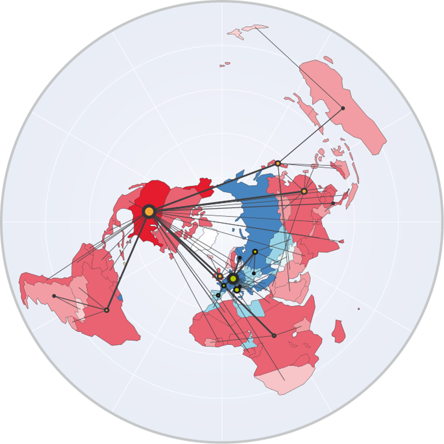

Les USA qui sont le principal importateur en 2006 domine la plus grande partie du Monde, à l’exception de la zone Europe Méditerranée qui est dominée par l’Allemagne.

## Domination des exportations en 2016-2020

[interactive chart not shown]

## Domination des importations en 2006

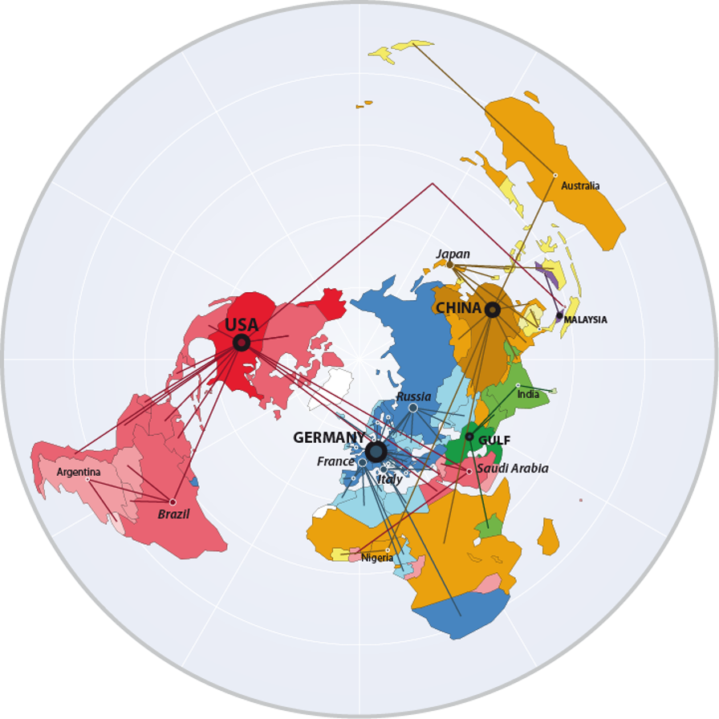

En 2006, trois grands pays exportateurs dominent les importations des autres pays du Monde : USA, Chine et Allemagne.

## Domination des importations en 2016-2020

[interactive chart not shown]

## Variante II : Domination sectorielle

La domination commerciale d’un pays porte rarement sur l’ensemble des produits. Il peut donc se créer un équilibre limitant les possibilités d’embargo ou de boycott. Deux exemples :

- **la domination des importations d’énergie** par les **pays exportateurs** qui peuvent refuser de vendre leur production de pétrole, gaz ou charbon.
- **la domination des importations agricoles** par les **pays exportateurs** qui peuvent refuser de vendre du blé, du maïs, du riz …

## Domination des ventes de produits énergétiques (2016-2020)

[interactive chart not shown]

## Domination des ventes de produits agricoles (2016-2020)

[interactive chart not shown]

## Variante III : Alliances commerciales

Nous avons supposé jusqu’ici que chaque pays était un acteur isolé développant une stratégie autonome. Mais il existe plusieurs cas de coordination des stratégies commerciales :

- **Cartels** destinés à coordonner les prix de certains produits. Un bon exemple est l’OPEP pour le pétrole.
- **Unions douanières** destinées à réduire le coût des échanges internes à une zone tout en se protégeant des concurrents externes. L’exemple typique est l’Union Européenne.

## Flux dominants bilatéraux 2016-2020 (UE27)

[interactive chart not shown]

## Do it yourself : export de mon pays

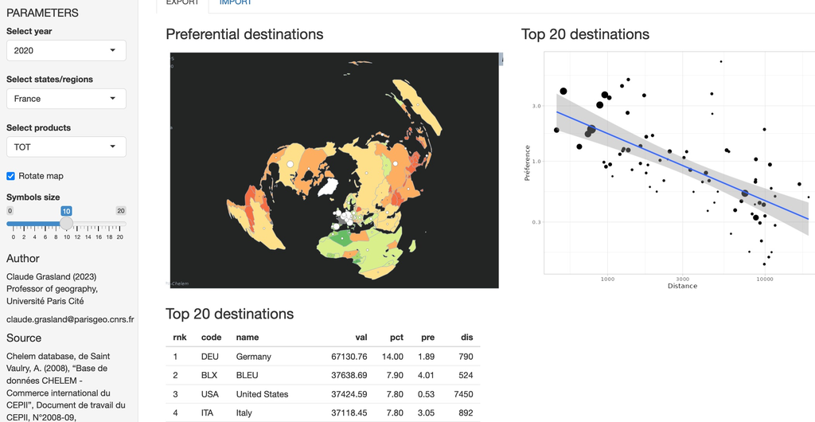

[Explorateur Chelem](https://analytics.huma-num.fr/Claude.Grasland/chelem/)

## Do it yourself : import de mon pays

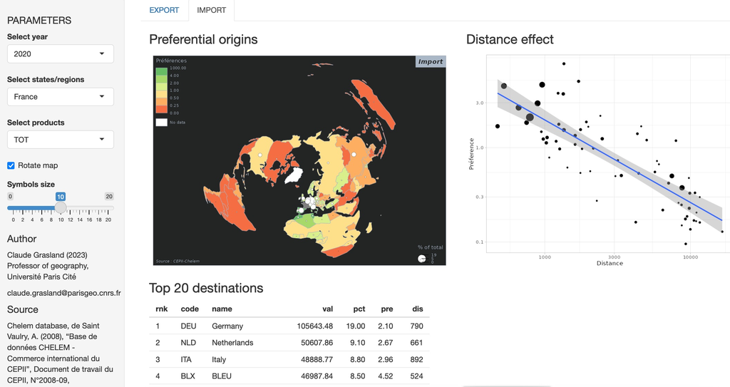

[Explorateur Chelem](https://analytics.huma-num.fr/Claude.Grasland/chelem/)

# Evolution de la division internationale du travail

## Lectures recommandées

- **Amin, S. (1971).** *L’accumulation à l’échelle mondiale: critique de la théorie du sous-développement*. Paris: Anthropos.
- **Reynaud, A. (1981)** *Société, espace et justice*, Paris, PUF, coll. Espace et Liberté.
- **Wallerstein, I. M. (2004)**. *World-systems analysis: An introduction*. Duke University Press.
- **Grasland, C., & Van Hamme, G. (2010).** La relocalisation des activités industrielles: une approche centre-périphérie des dynamiques mondiale et européenne. *L’espace géographique*, 39(1), 1-19.

## Le modèle Centre-Périphérie

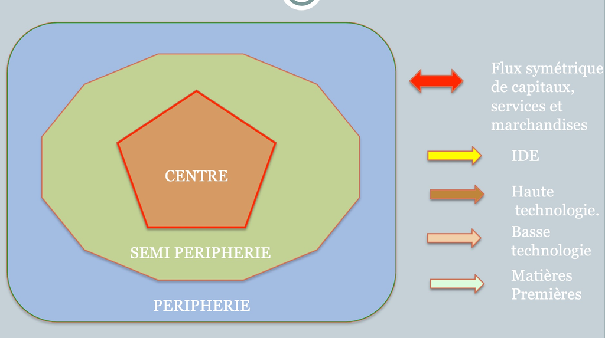

## Le modèle Centre-Périphérie

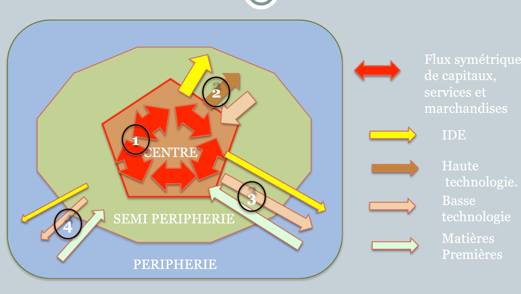

## Le modèle Centre-Périphérie

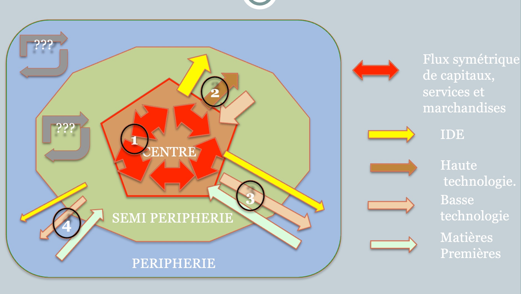

## Situation en 2006

- **Les produits énergétiques** : constituent un secteur stratégique inégalement réparti entre pays.
- **Les matières premières et produits agricoles** : constituent en général une première étape de développement. Mais ils ont aussi un rôle stratégique pour l’alimentation (e.g. blé, riz) ou l’industrie (e.g. terres rares)
- **Les produits manufacturiers de basse, moyenne ou haute technologie** : ont des localisations très différentes selon le rapport capital/ travail/ technologie qui intervient dans leurs chaînes de production.

## Exportations par produits en 2006

Quelle est la nature des exportations de chaque pays ?

Comment les pays se positionnent-ils dans la division internationale du travail ?

=> Synthèse des pays par Analyse en Composantes Principales (ACP)

## Exportations par produits en 2006

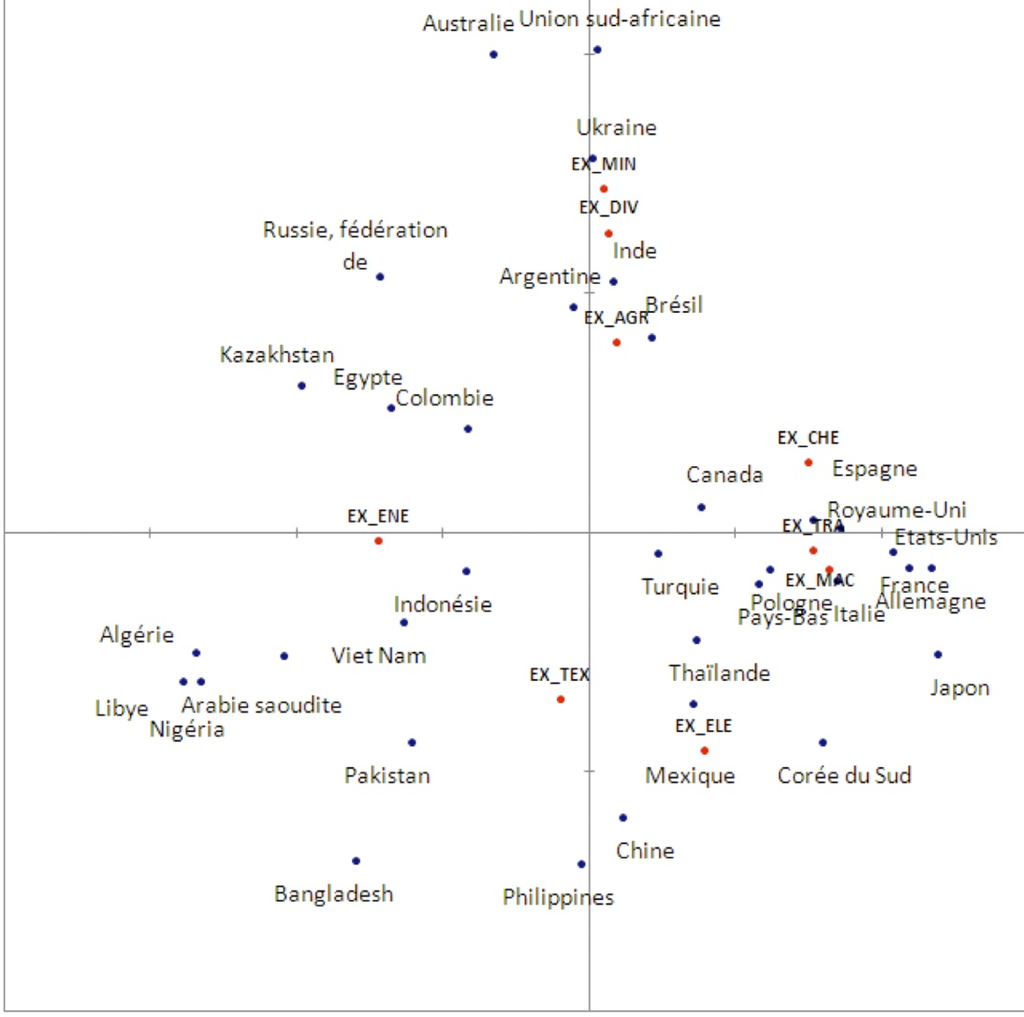

## Exportations par produits en 2006

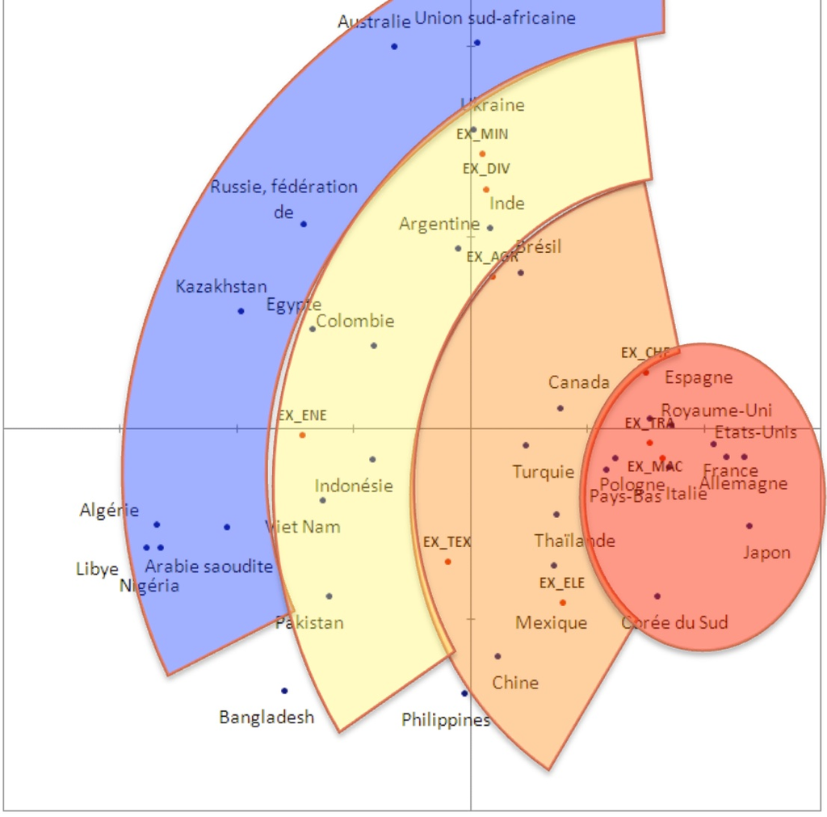

## Typologie des pays 1967-2006

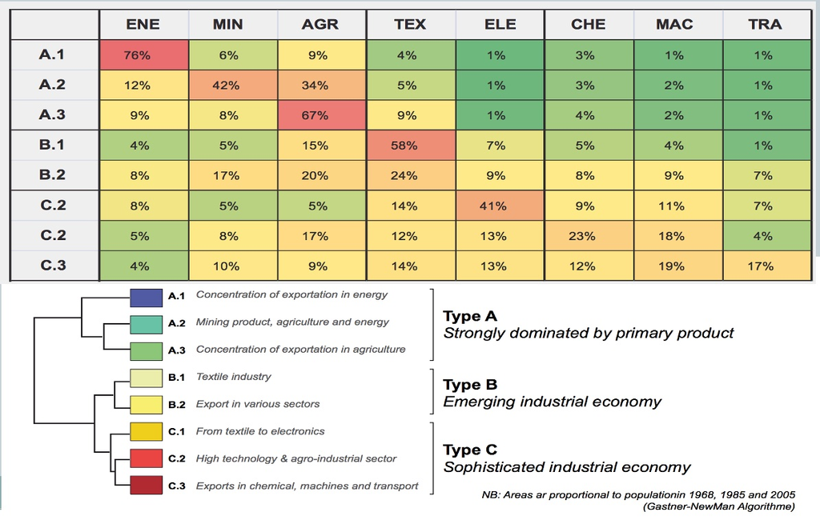

Source : Grasland, 2014

## Le temps des décolonisations

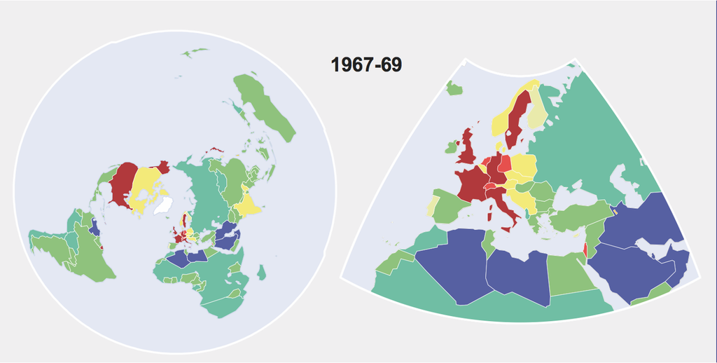

Source : Grasland, 2014

## La fin de la Guerre Froide

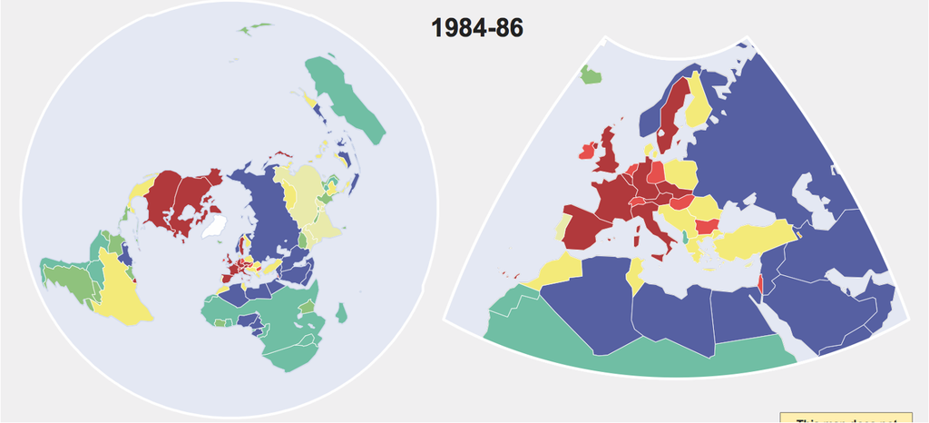

Source : Grasland, 2014

## Avant la crise des subprimes

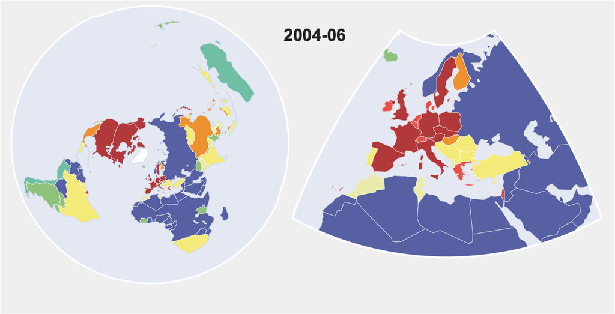

Source : Grasland, 2014

## Synthèse de l’évolution 1967-2006

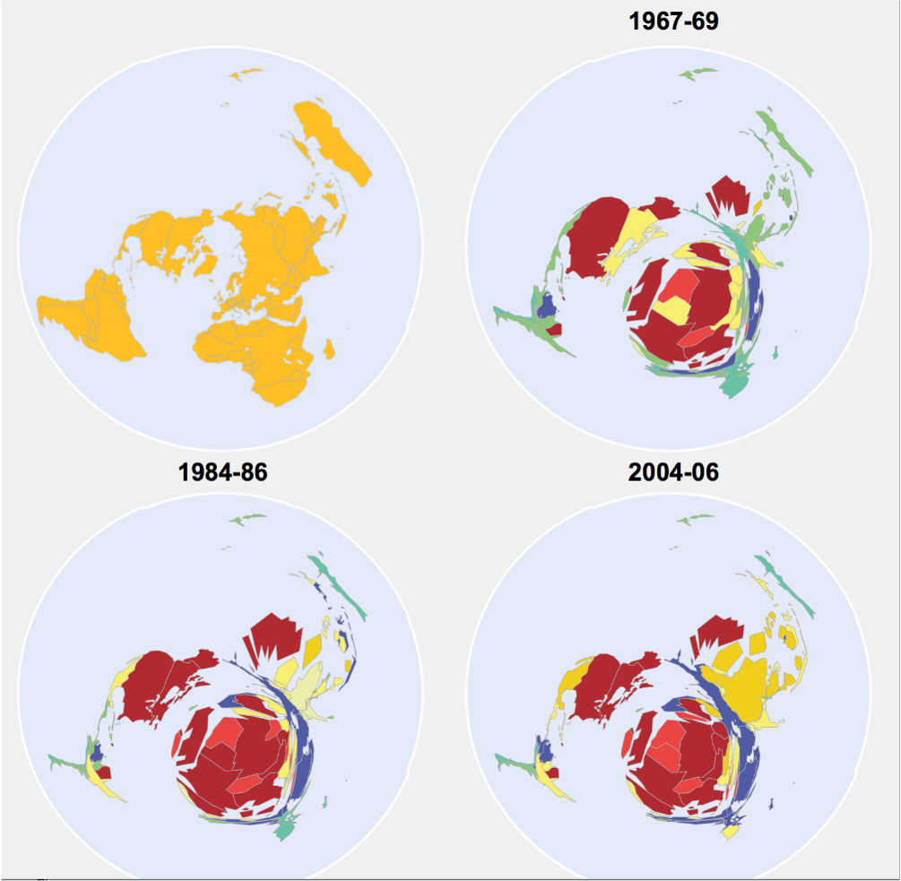

- **Montée en puissance des pays émergents** en particulier la Chine, l’Inde, le Mexique.
- **Diffusion des productions manufacturières** autour des anciens centres
- **Malédiction de la rente énergétique** dans des pays situés pour la plupart autour de l’Union Européenne (Russie, Algérie …)
- **Dépréciation des produits agricoles** et marginalisation des pays africains dans le commerce mondial

# Conclusion : fragilité des chaînes de valuer

## Exemple de la crise du Covid

### Coronavirus : les usines chinoises à l’arrêt, l’industrie européenne s’inquiète

Apple, Fiat Chrysler, Adidas… Le ban et l’arrière-ban de l’économie mondiale sont aujourd’hui touchés par la paralysie de la Chine, où l’épidémie due au coronavirus a déjà fait 722 morts et contaminé plus de 34 500 personnes depuis fin décembre 2019.

Avec l’hyperspécialisation des chaînes de valeur, il devient de plus en plus diffi-cile de remplacer un fournisseur par un autre », explique Ludovic Subran, chef économiste du groupe d’assurance allemand Allianz.

Au fil des ans, la Chine est devenue l’un des centres névralgiques de l’économie internationale, se muant en atelier du monde. « La part de l’Europe dans les chaînes de valeur mondiales s’est amenuisée au profit de la Chine, ajoute Alicia Garcia-Herrero, chef économiste pour la région Asie-Pacifique chez Natixis. Le pays concurrence même l’Allemagne dans la vente de produits intermédiaires sur le Vieux Continent.

C’est un nouveau coup dur pour le Vieux Continent, déjà pénalisé par l’accord commercial signé entre Pékin et Washington en janvier. La Chine s’est engagée à acheter lors de ces deux prochaines années pour 200 mil-liards de dollars (182,4 milliards d’euros) de produits américains supplémentaires, notamment agricoles et manufacturiers, au risque de diminuer ses importations en provenance d’Europe.

[figure not shown]

Le Monde, 7 février 2020

## Exemple de la guerre russo-urkrainienne

### L’accord céréalier au cœur d’une nouvelle épreuve de force entre Poutine et Zelensky

C’est le 17 juillet qu’expire, à nouveau, l’accord sur les céréales ukrainiennes. Nouvelle occasion d’un bras de fer (diplomatique) dans le bras de fer (militaire), dont les conséquences pour l’Afrique risquent d’être très lourdes.

Sans l’application de l’accord sur les exportations de céréales ukrainiennes, le gap sur le marché mondial devrait conduire à une nouvelle envolée des prix des denrées, ce qui accentuerait la crise alimentaire de pays africains qui, pourtant, n’auraient effectivement pas été destinataires des cargaisons. Le 14 juillet, en exhor-tant la Russie à reconduire l’accord, le secrétaire d’État américain Antony Blinken anticipait, dans le cas con-traire, une « aggravation de la pénurie alimentaire ».

[figure not shown]

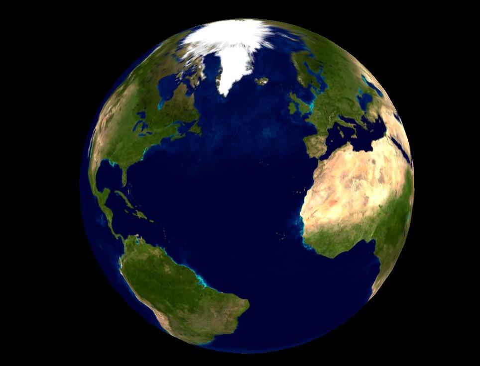